# CS 545 Homework II (Made By Oğulcan Emre Örsel)

Let's import the libraries

```python
import numpy as np
import scipy
from scipy.io import wavfile
from scipy import signal
from scipy.fft import fftshift
import matplotlib.pyplot as plt
from numpy import linalg
from scipy.sparse.csgraph import floyd_warshall
from scipy.spatial.distance import cdist
from scipy.sparse import csr_matrix
from numpy import inf
from scipy.signal import stft
```

## Question 1

We first plot the input signal

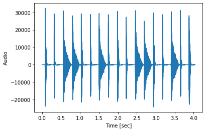

```python
root_path = 'C:/Users/Ogulcan/Desktop/CS 545' # Change current path to the desired one
subject_name = 'vl1'
full_path = '%s' % (root_path)

fs, audio = scipy.io.wavfile.read('vl1.wav')

#fs=float(fs)
audio = audio.astype(float)

N=np.shape(audio)[0]
time=np.arange(N) / float(fs) # in secs
window_size=1024

plt.plot(time, audio)
plt.ylabel('Audio')
plt.xlabel('Time [sec]')
plt.show()
```

We then calculate the spectrogram of the input signal

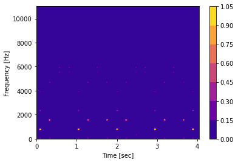

```python
f, t, Sxx = stft(audio, fs,window=('hamming'),nperseg=window_size,noverlap=window_size*3/4)
Sxx=abs(Sxx)/np.max(abs(Sxx))
plt.contourf(t, f, Sxx,cmap = 'plasma')
plt.ylabel('Frequency [Hz]')
plt.xlabel('Time [sec]')
plt.colorbar()
#plt.clim(-15, 0)
plt.show()
```

We then define the PCA algorithm as below

```python
def PCA_weights(X,num_components):

    cov_mat = np.cov(X)

    eigen_values , eigen_vectors = np.linalg.eigh(cov_mat)

    sorted_index = np.argsort(eigen_values)[::-1]
    sorted_eigenvalue = eigen_values[sorted_index]
    sorted_eigenvectors = eigen_vectors[:,sorted_index]

    eigenvector_subset = sorted_eigenvectors[:,0:num_components]
    eigenvalue_subset = np.sqrt(sorted_eigenvalue[0:num_components])

    eigenvalue_subset_matrix=np.eye(np.shape(eigenvalue_subset)[0])*eigenvalue_subset
    W=np.matmul(linalg.inv(eigenvalue_subset_matrix),eigenvector_subset.T)

    return W, eigenvector_subset, eigenvalue_subset
```

Running the PCA algorithm with 3 features:

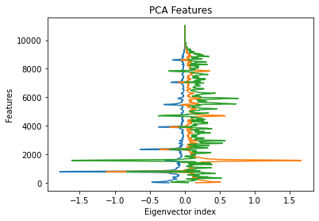

```python
W_PCA,v_PCA,w_PCA=PCA_weights(Sxx,3)

plt.plot(W_PCA[0,:],f)
plt.plot(W_PCA[1,:],f)
plt.plot(W_PCA[2,:],f)
plt.ylabel('Features')
plt.xlabel('Eigenvector index')
plt.title('PCA Features')
plt.show()
```

We then implement ICA:

```python
def ICA_weights(signals, iterations=100):
    m, n = signals.shape

    #W = np.random.rand(m, m) # Initialize W
    W=np.ones([m,m])
    for c in range(m):
            w = W[c, :].copy().reshape(m, 1)
            w = w / np.sqrt((w ** 2).sum())

            i = 0
            lim = 100
            while ((i < iterations)):

                # Fast ICA
                ws = np.dot(w.T, signals)

                wg_left = np.tanh(ws).T

                wg_right = (1 - np.square(np.tanh(ws)))

                wNew = (signals * wg_left.T).mean(axis=1) - wg_right.mean() * w.squeeze()

                wNew = wNew - np.dot(np.dot(wNew, W[:c].T), W[:c])
                wNew = wNew / np.sqrt((wNew ** 2).sum())

                lim = np.abs(np.abs((wNew * w).sum()) - 1)

                #print('%d',lim)

                w = wNew

                i += 1

            W[c, :] = w.T
    return W
```

We plot the results as below:

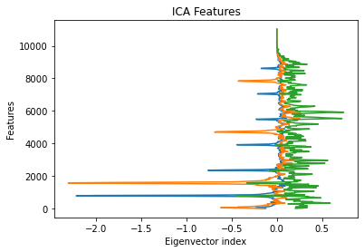

```python
Sxx_PCA=np.dot(W_PCA,Sxx)
W_ICA=ICA_weights(Sxx_PCA)

Sxx_ICA=np.matmul(W_ICA,Sxx_PCA)

W_ICA_final=np.dot(W_ICA,W_PCA)

plt.plot(W_ICA_final[0,:],f)
plt.plot(W_ICA_final[1,:],f)
plt.plot(W_ICA_final[2,:],f)
plt.ylabel('Features')
plt.xlabel('Eigenvector index')
plt.title('ICA Features')
plt.show()
```

We then define NMF

```python
def nmf(X, latent_features, max_iter=300, error_limit=1e-6, fit_error_limit=1e-6):
    """
    Decompose X to W*H
    """
    eps = 1e-5
    print('Starting NMF decomposition with {} latent features and {} iterations.'.format(latent_features, max_iter))

    mask = np.sign(X)

    rows, columns = np.shape(X)
    W = np.random.rand(rows, latent_features)
    W = np.maximum(W, eps)

    H = linalg.lstsq(W, X,rcond=-1)[0]
    H = np.maximum(H, eps)

    masked_X = mask * X
    X_est_prev = np.dot(W, H)
    for i in range(1, max_iter + 1):

        top = np.dot(masked_X, H.T)
        bottom = (np.dot((mask * np.dot(W, H)), H.T)) + eps
        W *= top / bottom

        W = np.maximum(W, eps)

        top = np.dot(W.T, masked_X)
        bottom = np.dot(W.T, mask * np.dot(W, H)) + eps
        H *= top / bottom
        H = np.maximum(H, eps)

        if i == max_iter:
            print('Iteration {}:'.format(i)),
            X_est = np.matmul(W, H)
            err = mask * (X - X_est)
            fit_residual = np.sqrt(np.sum(err ** 2))
            print('fit residual', np.round(fit_residual, 4))

    return W, H
```

```python
[A,Y]=nmf(Sxx.T,3)
```

```
Starting NMF decomposition with 3 latent features and 300 iterations.
Iteration 300:
fit residual 2.4253
```

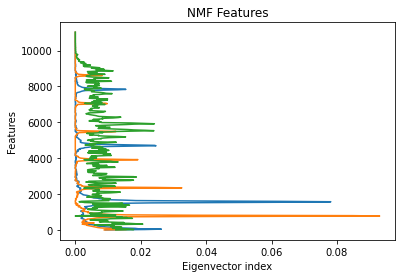

```python
plt.plot(Y[0,:],f)
plt.plot(Y[1,:],f)
plt.plot(Y[2,:],f)
plt.ylabel('Features')
plt.xlabel('Eigenvector index')
plt.title('NMF Features')
plt.show()
```

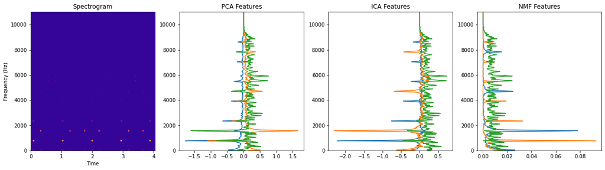

```python
fig, axs = plt.subplots(1, 4)

axs[0].contourf(t, f, Sxx,cmap = 'plasma')
axs[0].set_xlabel('Time')
axs[0].set_ylabel('Frequency (Hz)')
axs[0].set_title('Spectrogram')

axs[1].plot(W_PCA[0,:],f)
axs[1].plot(W_PCA[1,:],f)
axs[1].plot(W_PCA[2,:],f)
axs[1].set_ylim([0,11025.0])
axs[1].set_title('PCA Features')

axs[2].plot(W_ICA_final[0,:],f)
axs[2].plot(W_ICA_final[1,:],f)
axs[2].plot(W_ICA_final[2,:],f)
axs[2].set_ylim([0,11025.0])
axs[2].set_title('ICA Features')

axs[3].plot(Y[0,:],f)
axs[3].plot(Y[1,:],f)
axs[3].plot(Y[2,:],f)
axs[3].set_ylim([0,11025.0])
axs[3].set_title('NMF Features')



#plt.clim(-15, 0)

fig.set_figheight(5)
fig.set_figwidth(20)
```

# Question 2

We first import the images:

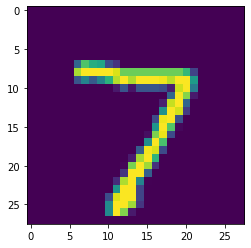

```python
dfile = "digits-labels_2.npz"
digits = np.load(dfile)["d"]

plt.ion()
plt.figure()
plt.imshow(np.reshape(digits[:,0],(28,28),'F'))
```

We apply PCA to the digits:

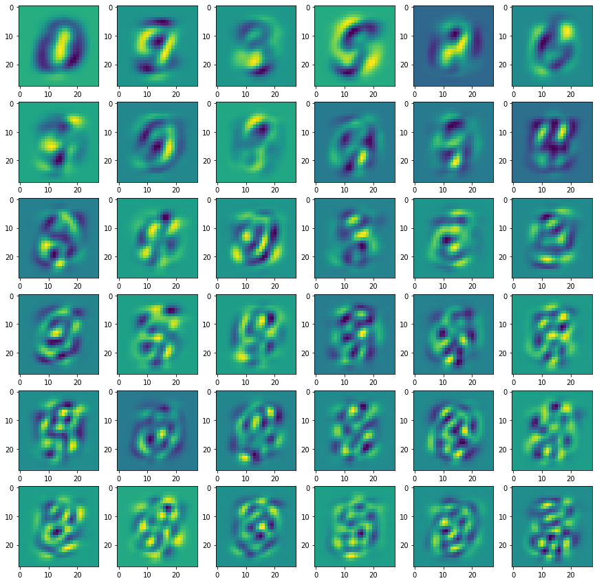

```python
W_digits_PCA,v_digits_PCA,w_digits_PCA=PCA_weights(digits,36)
digits_PCA=np.matmul(W_digits_PCA,digits)


[row,column]=np.shape(W_digits_PCA)

fig, axs = plt.subplots(6, 6)
for i in range(0,6):
    for j in range (0,6):
        axs[i, j].imshow(np.reshape(W_digits_PCA[j+i*6,:],(28,28),'F'))
        #axs[i, j].set_title('Feature  '+str(j+i*6))
fig.set_figheight(15)
fig.set_figwidth(15)
```

We again observe that PCA extracts the main features of the digits by decorrelating the input signal. We see from the above that the features look like the mixtures of the different numbers as in the case of eigenvalues.

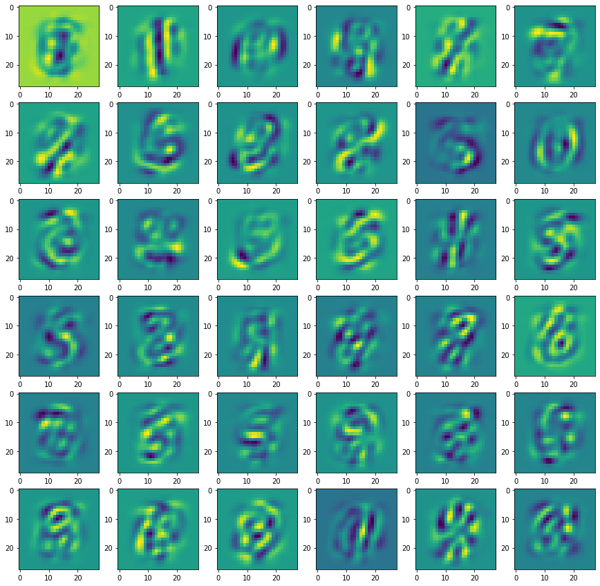

```python
W_digits_ICA=ICA_weights(digits_PCA)

W_digits_ICA_final=np.transpose(np.dot(W_digits_ICA,W_digits_PCA))

fig, axs = plt.subplots(6, 6)
for i in range(0,6):
    for j in range (0,6):
        axs[i, j].imshow(np.reshape(W_digits_ICA_final[:,j+i*6],(28,28),'F'))
        #axs[i, j].set_title('Feature  '+str(j+i*6))
fig.set_figheight(15)
fig.set_figwidth(15)
```

When we look at the ICA features, we see that ICA selects more distinct features to make the output signals independent. At this point it is hard to tell the exact difference with PCA, but it is easy to say that features of the ICA is sharper than PCA.

```python
[W_digits_NMF,H_digits_NMF]=nmf(digits,36)
```

```
Starting NMF decomposition with 36 latent features and 300 iterations.
Iteration 300:
fit residual 297.9462
```

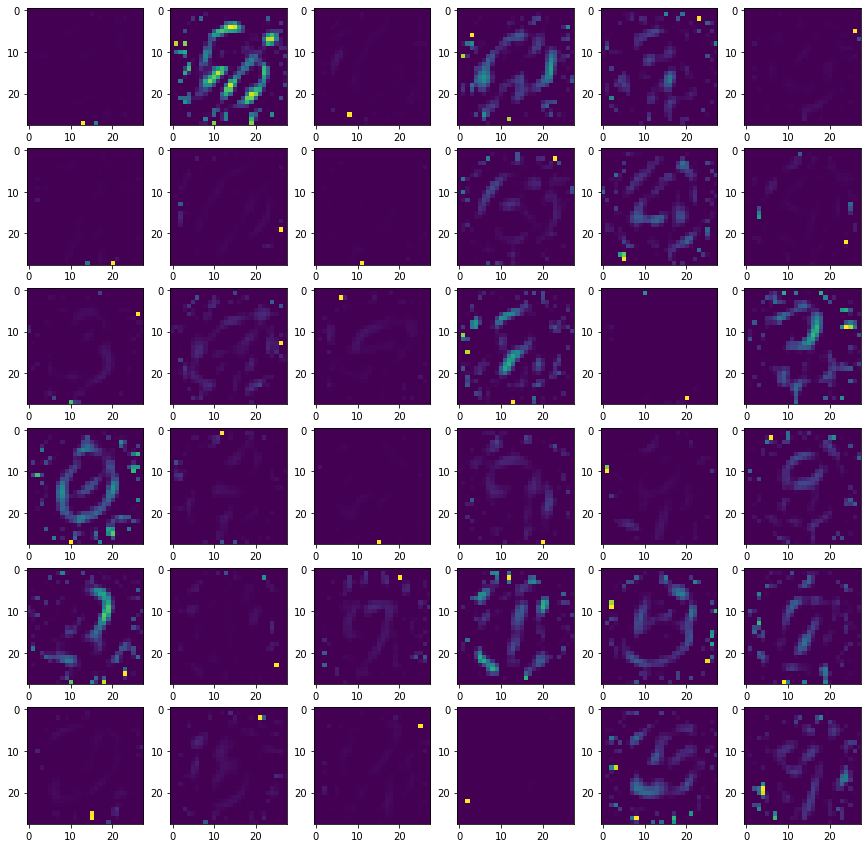

```python
[row,column]=np.shape(W_digits_NMF.T)

W_digits_NMF_trans=W_digits_NMF.T

fig, axs = plt.subplots(6, 6)
for i in range(0,6):
    for j in range (0,6):
        axs[i, j].imshow(np.reshape(W_digits_NMF_trans[j+i*6,:].T,(28,28),'F'))
        #axs[i, j].set_title('Feature  '+str(j+i*6))
fig.set_figheight(15)
fig.set_figwidth(15)
```

When we look at NMF features, they are definetely different than ICA and PCA. Also , it is hard to understand since NMF decomposes the features like additive noise (each feauture adds up to make a single digit). Both ICA and NMF are good at identifying elements and sharp features and hence they are good at discovering distinctive elements.

# Question 3

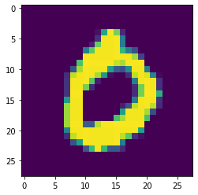

```python
digits_NMF=np.dot(W_digits_NMF,H_digits_NMF)
plt.imshow(np.reshape(digits[:,3],(28,28),'F'))
```

```python
dfile = "digits-labels_2.npz"
digits = np.load(dfile)["d"]
numbers = np.load(dfile)["l"]

mask=(numbers==6)*1
digit_6=np.zeros([np.shape(digits)[0],np.sum(mask)])
p=0
for i in range(0,np.shape(digits)[1]):
    if mask[i]==1:
        digit_6[:,p]=digits[:,i]
        p=p+1
```

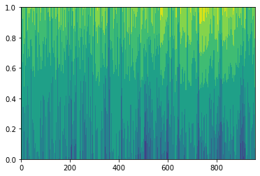

```python
W_digit_6_PCA,v_6_PCA,w_6_PCA=PCA_weights(digit_6,2)

np.shape(W_digit_6_PCA)
digit_6_PCA=np.matmul(W_digit_6_PCA,digit_6)

plt.contourf(digit_6_PCA)
plt.show()
```

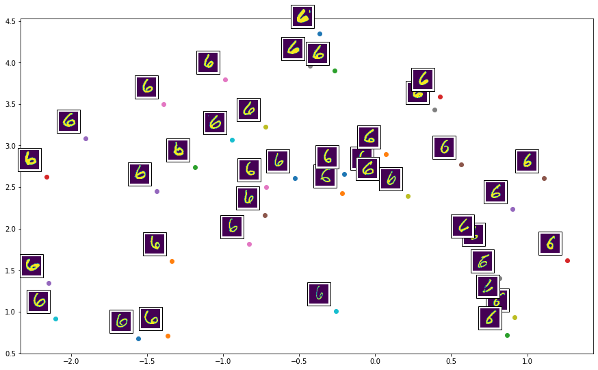

```python
import matplotlib.pyplot as plt
import numpy as np

from matplotlib.patches import Circle
from matplotlib.offsetbox import (TextArea, DrawingArea, OffsetImage,
                                  AnnotationBbox)
from matplotlib.cbook import get_sample_data

fig, ax = plt.subplots()

final_plot=np.shape(digit_6_PCA)[1]

i=0
while i<final_plot:

    xy = (digit_6_PCA[0,i],digit_6_PCA[1,i])
    ax.scatter(xy[0],xy[1])

    arr = np.reshape(digit_6[:,i],(28,28),'F')
    im = OffsetImage(arr, zoom=1)
    im.image.axes = ax

    ab = AnnotationBbox(im,xy ,
                        xybox=(-25., 25.),
                        xycoords='data',
                        boxcoords="offset points",
                        pad=0.3)

    i=i+25
    ax.add_artist(ab)

fig.set_size_inches(15, 9, forward=True)
```

Here we are plotting the PCA results of the digit 6 and we can clearly see that our algorithm is good at distributing similar 6s to similar places. But we observe that distribution of the data is not really gaussian and we see that PCA cannot describe the data (since there is a topology of the data). So we need non-linear mapping as we will discover with ISOMAP that will map our data with its nearest neighbour.

```python
"""
def floyd_warshall(G):
    distance = list(map(lambda i: list(map(lambda j: j, i)), G))
    nV=np.shape(G)[0]
    # Adding vertices individually
    for k in range(nV):
        for i in range(nV):
            for j in range(nV):
                distance[i][j] = min(distance[i][j], distance[i][k] + distance[k][j])
    return distance
"""

def geodesic_dist(data, dist_func="euclidean", K=6):

    n, m = data.shape
    dist = cdist(data.T, data.T, metric=dist_func)
    adj =  np.zeros((m, m)) + np.inf
    k_nb =  np.zeros((m, 1))

    for i in range(0,m):
        k_nb[i,0]=np.max(np.partition(dist[:,i],K)[:K])

    bln = dist < k_nb
    adj[bln] = dist[bln]
    #short = graph_shortest_path(adj)
    graph = csr_matrix(adj)
    short = floyd_warshall(graph)
    short[short==inf]=0

    return short


def isomap(d, dim=2):

    n, m = d.shape
    h = np.eye(m) - (1/m)*np.ones((m, m))
    d = d**2
    c = -1/(2*m) * h.dot(d).dot(h)
    evals, evecs = linalg.eig(c)
    idx = evals.argsort()[::-1]
    evals = evals[idx]
    evecs = evecs[:, idx]
    evals = evals[:dim]
    evecs = evecs[:, :dim]
    z = evecs.dot(np.diag(evals**(-1/2)))

    return z.real
```

```python
d=geodesic_dist(digit_6)
digit_6_isomap=np.transpose(isomap(d, dim=2))
```

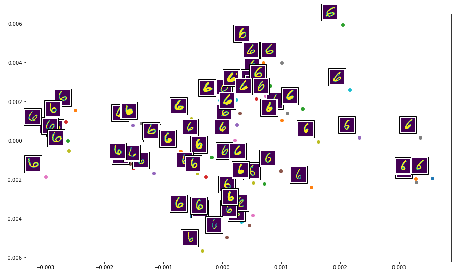

```python
import matplotlib.pyplot as plt
import numpy as np

from matplotlib.patches import Circle
from matplotlib.offsetbox import (TextArea, DrawingArea, OffsetImage,
                                  AnnotationBbox)
from matplotlib.cbook import get_sample_data

fig, ax = plt.subplots()

final_plot=np.shape(digit_6_isomap)[1]

i=0
while i<final_plot:

    xy = (digit_6_isomap[0,i],digit_6_isomap[1,i])
    ax.scatter(xy[0],xy[1])

    arr = np.reshape(digit_6[:,i],(28,28),'F')
    im = OffsetImage(arr, zoom=1)
    im.image.axes = ax

    ab = AnnotationBbox(im,xy ,
                        xybox=(-25., 25.),
                        xycoords='data',
                        boxcoords="offset points",
                        pad=0.3)

    i=i+15
    ax.add_artist(ab)

fig.set_size_inches(15, 9, forward=True)
```

When we look at the ISOMAP, we see that our 6 nearest neighbour mapping transforms the data into a lower dimension (more of an elliptical shape) due to the fact that only a small fractions are changing for every different 6. So we can represent our data in a lower dimension. Actually, that sample is very similar to the pose example that is given at the lecture. This proves that using a geodesic distance algorithm reduces our dimension significantly since the change in every pose is very small (only a small fraction of the image).